# Phân loại người sống sót trên tàu Titanic

### 3.2. Hiển thị dữ liệu (Visualize Data) - Graphic Approach

#### (1) Hiển thị trên từng tính chất đơn (Univariate Plots)

##### Khả năng sống sót (Surviced Label)

[output not shown]

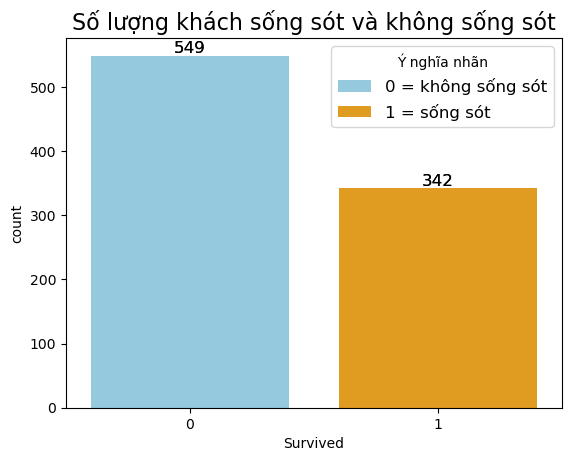

```python
ax = sns.countplot(x='Survived', data=train_df, palette=["skyblue", "orange"])
sns.countplot(x='Survived', data=train_df, palette=["skyblue", "orange"],legend=True)
for container in ax.containers:
    ax.bar_label(container, fmt='%d', label_type='edge', fontsize=12, color='black')
plt.legend(["0 = không sống sót", "1 = sống sót"], title="Ý nghĩa nhãn", fontsize=12)
plt.title("Số lượng khách sống sót và không sống sót", fontsize=16)
plt.show()
```

**Nhận xét**:

- Số lượng hành khách không sống sót (549 người) cao hơn đáng kể so với số lượng hành khách sống sót (342 người).
- Phần lớn hành khách đã không qua khỏi, số người không sống sót chiếm khoảng 61,6% tổng số hành khách được thống kê.

[output not shown]

[figure not shown]

```python
ax = sns.countplot(x='Embarked', data=train_df, palette=["skyblue", "orange", "lightgreen"])
sns.countplot(x='Embarked', data=train_df, palette=["skyblue", "orange", "lightgreen"],legend=True)
for container in ax.containers:
    ax.bar_label(container, fmt='%d', label_type='edge', fontsize=12, color='black')
plt.legend(["C: Cherbourg (Pháp)", "Q: Queenstown (Ireland)", "S: Southampton (Anh)"], title="Ý nghĩa nhãn", fontsize=12)
plt.title("Số lượng khách theo cảng lên tàu", fontsize=16)
plt.show()
```

**Nhận xét:**

- Cảng Southampton (S) chiếm đa số áp đảo, với gần 2/3 tổng số hành khách. Điều này cho thấy phần lớn hành khách Titanic lên tàu tại Anh, có thể do đây là điểm khởi hành chính của con tàu.
- Cảng Cherbourg (C) chiếm khoảng 17–18%, ít hơn nhiều so với Southampton. Đây có thể là nhóm hành khách trung – thượng lưu từ châu Âu lục địa.
- Cảng Queenstown (Q) chỉ chiếm khoảng 7–8%, là ít nhất trong ba cảng. Có thể đây là những hành khách có hoàn cảnh khiêm tốn hơn, hoặc chỉ di chuyển quãng ngắn.

##### Box and whisker plots

- https://www.simplypsychology.org/boxplots.html
- So sánh các trung vị (median) tương ứng của mỗi ô hộp (box plot). Nếu đường trung vị của một ô hộp nằm bên ngoài ô của một ô hộp so sánh, thì có thể có sự khác biệt giữa hai nhóm.
- So sánh chiều dài hộp để kiểm tra cách dữ liệu được phân tán giữa mỗi mẫu. Hộp càng dài thì dữ liệu càng phân tán. Dữ liệu càng nhỏ càng ít bị phân tán.
- Một ngoại lệ (outlier) được định nghĩa là một điểm dữ liệu nằm bên ngoài phần rìa (whiskers) của ô hộp.
- Kiểm tra hướng lệch của dữ liệu (cân đối, các phần tử tập trung trái, phải).
  - Median ở giữa hộp và râu (whiskers) ở hai bên như nhau thì phân bố là đối xứng.
  - Median ở gần đáy hộp hơn và nếu râu ngắn hơn ở đầu dưới của hộp, thì phân phối là lệch dương (lệch phải).
  - Median ở gần đầu hộp hơn và nếu râu ngắn hơn ở đầu trên của hộp, thì phân bố bị lệch âm (lệch trái).

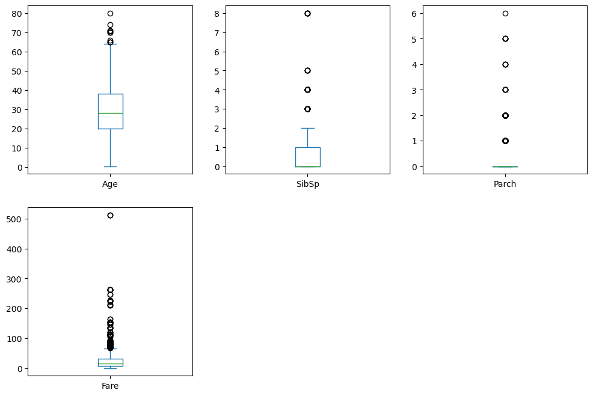

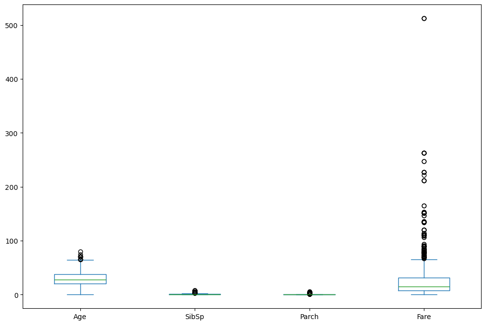

```python
train_df.drop(['Survived', 'Pclass'], axis=1).plot(kind="box", subplots=True, layout=(2, 3), sharex=False, sharey=False, figsize=(12,8))
train_df.drop(['Survived', 'Pclass'], axis=1).plot(kind="box", figsize=(12,8))
```

**Nhận xét**:

- Phân tích từng biến:
  - Age (Tuổi): Độ tuổi phân bố chủ yếu từ khoảng 20 đến 38 (phần thân hộp). Đường trung vị khoảng 28-30 tuổi. Có một số giá trị ngoại lệ (outliers) là những người lớn tuổi (các dấu chấm tròn).
  - SibSp (Số anh chị em/vợ chồng): Hầu hết hành khách (hơn 75%) có giá trị là 0 hoặc 1 (trung vị là 0). Có nhiều giá trị ngoại lệ, cho thấy một số gia đình có đông thành viên.
  - Parch (Số cha mẹ/con cái): Tương tự như SibSp, hầu hết hành khách có giá trị là 0. Cũng có nhiều giá trị ngoại lệ.
  - Fare (Giá vé): Phân bố này bị lệch phải rất mạnh. Hầu hết giá vé rất thấp (phần hộp bị nén ở phía dưới, trung vị < 20), nhưng có rất nhiều giá trị ngoại lệ (outliers) rất cao, lên đến hơn 500.
- So sánh các biến:
  - Có thể thấy rõ ràng rằng cột Fare (do các outliers) có thang đo lớn nhất, trong khi các biến còn lại (Age, SibSp, Parch) có thang đo nhỏ hơn nhiều.
  - SibSp, Parch đây là ba biến này vẫn bị "đè bẹp" (squashed) hoàn toàn ở phía dưới cùng. Lý do là vì giá trị tối đa của chúng (ngay cả khi tính cả outliers, ví dụ SibSp tối đa là 8) vẫn quá nhỏ so với thang đo 0-500 của biểu đồ.

##### Biểu đồ Histogram

```
array([[<Axes: title={'center': 'Survived'}>,
        <Axes: title={'center': 'Pclass'}>],
       [<Axes: title={'center': 'Age'}>,
        <Axes: title={'center': 'SibSp'}>],
       [<Axes: title={'center': 'Parch'}>,
        <Axes: title={'center': 'Fare'}>]], dtype=object)
```

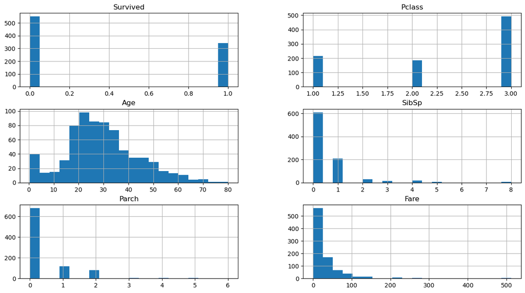

```python
train_df.hist(figsize=(15, 8), bins = 20)
```

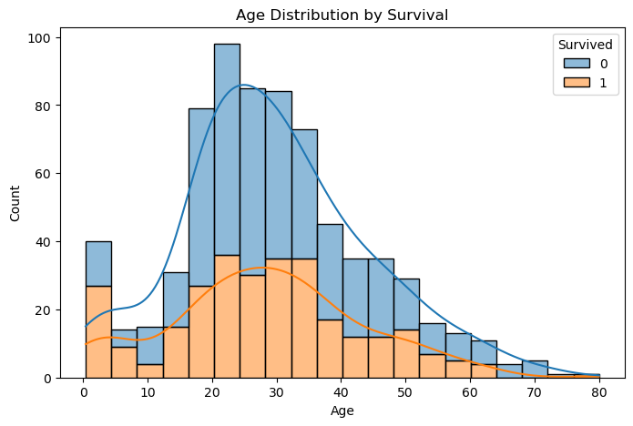

```python
plt.figure(figsize=(8,5))
sns.histplot(data=train_df, x='Age', hue='Survived', multiple='stack', kde=True)
plt.title('Age Distribution by Survival')
plt.show()
```

**Nhận xét**:

##### Density Plots

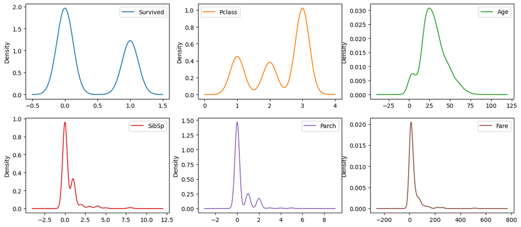

```python
train_df.plot(kind='density', subplots=True, layout=(3,3), sharex=False, figsize=(15, 10))
plt.show()
```

#### (2) Hiển thị nhiều tính chất (Multivariate Plots) using comparison graphs

##### Barplot

- Giới tính tác động tới khả năng sống sót

[output not shown]

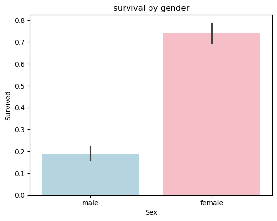

```python
sns.barplot(x = 'Sex', y = 'Survived', data = train_df, palette=["lightblue", "lightpink"])
plt.title('survival by gender')
plt.show()
```

**Nhận xét**:

[output not shown]

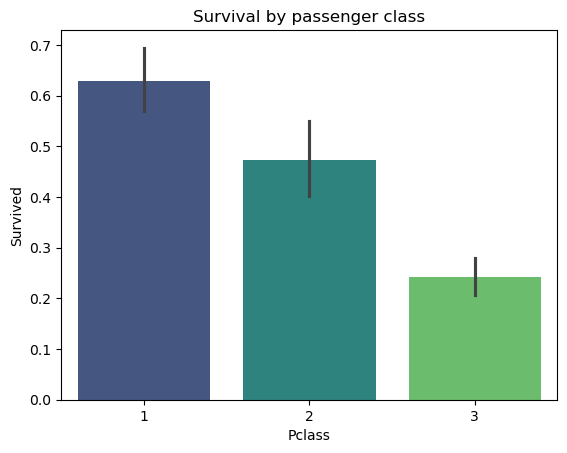

```python
sns.barplot(x = 'Pclass', y = 'Survived', data = train_df, palette="viridis")
plt.title("Survival by passenger class")
plt.show()
```

**Nhận xét**: